# Fetch Project: Similarity Search via Text Inputs

## Developed by Chen Zhang, 7/30/2023

## 1. Introduction

### 1.1 Problem Statement

We were provided with a dataset of offers and associated metadata, such as the retailers and brands that sponsor the offer. We were also provided with a dataset of brands that we support on our platform, and the categories to which those products belong.

The goal is to develop a tool to perform the following queries:

- **Category search**: If a user searches for a category (e.g., diapers), the tool should return a list of offers that are relevant to that category.
- **Brand search**: If a user searches for a brand (e.g., Huggies), the tool should return a list of offers that are relevant to that brand.
- **Retailer search**: If a user searches for a retailer (e.g., Target), the tool should return a list of offers that are relevant to that retailer.
- **Similarity score**: The tool also returns the score that was used to measure the similarity of the text input with each offer.

### 1.2 Outline

In this project, I developed a command-line tool that enables users to intelligently search for offers via text input from users. The tool is built on natural language processing (NLP) models for performing similarity search on a dataset of product categories. The methodology involves the following five aspects:

- **Similarity definition**: An NLP model is used to define the similarity metric that will be used to measure the similarity between two product categories.
- **Data cleaning**: The dataset of product categories is cleaned to remove any errors or inconsistencies.
- **Table operation**: The cleaned dataset is loaded into a database table.
- **Query search**: The user enters a query, and the NLP model is used to generate a list of product categories that are similar to the query.
- **Metrics analysis**: The results of the similarity search are analyzed to determine which metrics work best for certain types of queries.

- Training a sentence transformer model and using it to perform similarity search.
- Investigating the use of other NLP models for similarity search.
- Developing a user interface for the tool.

### 1.3 Run Locally

Please see Example.ipynb for details.

## 2. Production Pipeline

### 2.1 Libraries Prerequisite

This notebook requires the installation of the following packages:

- numpy: A library for scientific computing.
- pandas: A library for data analysis.
- sklearn: A library for machine learning.
- thefuzz: A library for fuzzy string matching.
- sentence_transformer: A library for sentence embedding.

To install these packages, you can use the following commands:

- pip install numpy
- pip install pandas
- pip install sklearn
- pip install thefuzz
- pip install sentence_transformer

Once you have installed the packages, you can load them into your notebook using the following code:

```python
import warnings
warnings.filterwarnings('ignore')
import numpy as np
import pandas as pd
import sklearn
from thefuzz import fuzz
from sentence_transformers import SentenceTransformer
import re
from sklearn.metrics.pairwise import cosine_similarity
pd.set_option('display.max_colwidth', 30)
```

### 2.2 Data Cleaning

My first step took in processing language data is **data cleaning**. It is important to remove noise from the data so that the machine can more easily detect patterns. Text data can contain a lot of noise, such as special characters and inconsistent capitalization. These elements can be difficult for computers to understand, so they need to be removed.

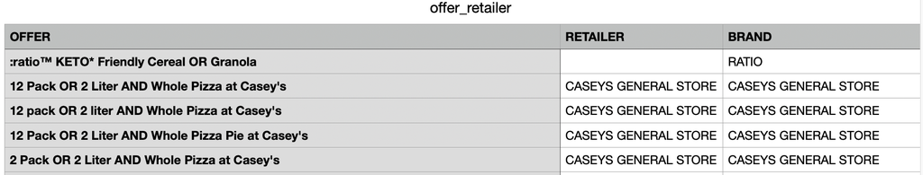

```python
def clean(file):
    # change to lower case
    df = pd.read_csv(file, dtype = str)
    for col in df.columns.values:
        df[col] = df[col].str.lower()

    # remove special characters in the offer column
    if file == 'offer_retailer.csv':
        for index, row in df.iterrows():
            txt = row['OFFER']
            df.loc[index, "OFFER"] = re.sub(r"[^a-z0-9 ]", "", txt)
    # remove duplicate rows
        df.drop_duplicates(subset=['OFFER'], inplace = True)
    return df
```

The three datasets were cleaned and the results are shown below. A few duplicate lines were removed from the offer_retailer file. Missing values in the Retailer column were filled with empty strings. The column names were also renamed for the purpose of future joining.

```python
# Offer_brand table
offer = clean('offer_retailer.csv')
offer.replace(np.nan,'',regex=True, inplace=True)
print(offer.head())
print(offer.shape)
```

```
                           OFFER            RETAILER        BRAND
0  spend 50 on a fullpriced n...           sams club    sams club
1  beyond meat plantbased pro...                      beyond meat
2  good humor viennetta froze...                       good humor
3  butterball select varietie...  dillons food store   butterball
4  gatorade fast twitch 12oun...              amazon     gatorade
(369, 3)
```

```python
brand = clean('brand_category.csv')
brand.rename(columns={"BRAND_BELONGS_TO_CATEGORY": "CATEGORY"}, inplace=True)
brand['RECEIPTS'] = pd.to_numeric(brand['RECEIPTS'])

print(brand.head())
print(brand.shape)
```

```
              BRAND          CATEGORY  RECEIPTS
0  caseys gen store  tobacco products   2950931
1  caseys gen store            mature   2859240
2            equate      hair removal    893268
3         palmolive       bath & body    542562
4              dawn       bath & body    301844
(9906, 3)
```

```python
category = clean('categories.csv')
category.rename(columns={"PRODUCT_CATEGORY": "CATEGORY",
                      "IS_CHILD_CATEGORY_TO": "PARENT_CATEGORY"}, inplace=True)

category.drop(columns=['CATEGORY_ID'], inplace = True)

print(category.head())
print(category.shape)
```

```
                      CATEGORY    PARENT_CATEGORY
0              red pasta sauce        pasta sauce
1  alfredo & white pasta sauce        pasta sauce
2             cooking & baking             pantry
3             packaged seafood             pantry
4             feminine hygeine  health & wellness
(118, 2)
```

### 2.3 Table Operation

The next step is to combine all tables into one master table for easier handling.

```python
# join the brand and category table, using pandas merge function which is equal to SQL inner join
brand_cat = brand.merge(category, right_on = ['CATEGORY'], left_on = ['CATEGORY'])

print(f'After joining the category (shape {category.shape}) and brand table (shape {brand.shape}), the output has shape of {brand_cat.shape}')
print(brand_cat.head())
```

```
After joining the category (shape (118, 2)) and brand table (shape (9906, 3)), the output has shape of (9906, 4)
               BRAND          CATEGORY  RECEIPTS    PARENT_CATEGORY
0   caseys gen store  tobacco products   2950931             mature
1  rj reynolds vapor  tobacco products        21             mature
2   caseys gen store            mature   2859240             mature
3             equate      hair removal    893268  health & wellness
4           barbasol      hair removal    283926  health & wellness
```

```python
full = offer.merge(brand_cat, how = 'left', right_on = ['BRAND'], left_on = ['BRAND'])
full.replace(np.nan,'',regex=True, inplace=True)

# rearrange columns
cols = ['OFFER', 'RETAILER', 'BRAND', 'CATEGORY', 'PARENT_CATEGORY', 'RECEIPTS']
full = full[cols]
print(full)
print(full.shape)
```

```
                             OFFER   RETAILER              BRAND  \
0    spend 50 on a fullpriced n...  sams club          sams club
1    beyond meat plantbased pro...                   beyond meat
2    beyond meat plantbased pro...                   beyond meat
3    beyond meat plantbased pro...                   beyond meat
4    good humor viennetta froze...                    good humor
..                             ...        ...                ...
792             thomas bagel thins                        thomas
793             thomas bagel thins                        thomas
794             thomas bagel thins                        thomas
795         spend 270 at pavilions  pavilions          pavilions
796  back to the roots soils se...    walmart  back to the roots

                    CATEGORY PARENT_CATEGORY RECEIPTS
0
1              packaged meat          pantry     30.0
2           plant-based meat  meat & seafood   1584.0
3    frozen plant-based meat          frozen    313.0
4               dips & salsa          snacks    596.0
..                       ...             ...      ...
792                   bakery   deli & bakery     24.0
793         frozen breakfast          frozen    258.0
794                    bread          pantry  26490.0
795         cooking & baking          pantry     15.0
796   packaged meals & sides          pantry    146.0

[797 rows x 6 columns]
(797, 6)
```

### 2.4 Basline Method: Similarity Search Based on Fuzzy String

In this section, I developed a baseline tool, called Fuzzy string, to perform similarity search. This method serves as a starting point which will be improved in the next section. Fuzzy string provides a ranked list of similarity scores based on several criteria, including ratio, partial ratio, token sort ratio, token set ratio, and partial token sort ratio. These criteria are used to measure the similarity between two strings.

To illustrate the use of these criteria, I consider the example of the input string "meat".

```python
name = "meat"
similarity = category.copy()
partialRatio, ratio, tokenSortRatio, tokenSetRatio, partialTokenSortRatio = [], [], [], [], []

for index, row in similarity.iterrows():
    val = row['CATEGORY']
    a = fuzz.partial_ratio(name, val)
    b = fuzz.ratio(name, val)
    c = fuzz.token_sort_ratio(name, val)
    d = fuzz.token_set_ratio(name, val)
    e = fuzz.partial_token_sort_ratio(name, val)
    partialRatio.append(a)
    ratio.append(b)
    tokenSortRatio.append(c)
    tokenSetRatio.append(d)
    partialTokenSortRatio.append(e)
similarity['Partial Ratio'] = partialRatio
similarity['Ratio'] = ratio
similarity['Token Sort Ratio'] = tokenSortRatio
similarity['Token Set Ratio'] = tokenSetRatio
similarity['Partial Token Set Ratio'] = partialTokenSortRatio

for criteria in ['Ratio', 'Partial Ratio', 'Token Sort Ratio', 'Token Set Ratio', 'Partial Token Set Ratio']:
    print(f'Top 10 matched category using {criteria}')
    print(similarity.nlargest(10, criteria)[['CATEGORY', criteria]])
    print()
```

```
Top 10 matched category using Ratio
             CATEGORY  Ratio
112            mature     60
52                tea     57
90      packaged meat     47
6               cream     44
51              bread     44
71              water     44
23         condiments     43
72   plant-based meat     40
74        fresh pasta     40
92             makeup     40

Top 10 matched category using Partial Ratio
                       CATEGORY  Partial Ratio
```

[output cut: 49 more lines]

Fuzzy search algorithms use edit distance to find strings that are similar to the input string. The lower the edit distance, the more similar the two strings are. However, edit distance does not take into account the *meaning* of the words. For example, the words "meat" and "meal" have different meanings, even though they have the same edit distance.

This is why it is important to carefully consider the results of a fuzzy search. Just because a string has a low edit distance to the input string does not mean that it is a good match. It is important to consider the meaning of the words in the string as well.

In the example of the input string "meat," the first few top-matched items may contain the word "meat" because it is a common word. However, the other words in the matched items may not make much sense, because they may be semantically unrelated to the input string. This is because fuzzy search algorithms do not take into account the meaning of the words when they are making their matches.

In the next section, I will use **semantic similarity** to improve the results of a fuzzy search. Semantic similarity is a measure of how similar the meanings of two strings are. By using semantic similarity, it is possible to find strings that are similar to the input string in terms of both their meaning and their edit distance.

### 2.5. Modern Method: Similarity Search Using Transfomer Model

In this section, I developed a number of transformer models for the task of similarity search. **Transformer models** are a type of neural network that have been shown to be very effective for natural language processing tasks. They are able to learn long-range dependencies between words, which makes them well-suited for tasks such as **semantic similarity** and natural language inference. Text/sentence similarity is one of the clearest examples of the power of transformer models. These models can be used to compute the similarity between two pieces of text, even if they are very different in length or structure. This makes them ideal for tasks such as category search, where the goal is to find documents that are similar to a given query.

The full model architecture is shown below. The model consists of the following layers:

-A **tokenization** layer that converts the text into a sequence of tokens.

-A **word embedding** layer that maps each token to a vector representation.

-A **Transformer** layer that learns to predict the next token in a sequence.

-A **pooling** layer that aggregates the output of the Transformer layer into a single vector representation.

-A **similarity** layer that computes the similarity between the query and the document representations.

The full model architecture is shown below.

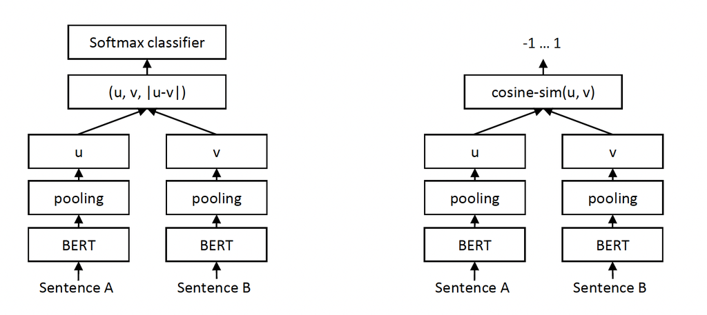

Here I provide step-by-step instructions on using transformer models for similarity search.

First, I create a **bert-base-nli-mean-tokens** model using the sentence_transformers library. This model can be used to map sentences and paragraphs to a 768-dimensional dense vector space, where the distance between two vectors is a measure of the semantic similarity between the sentences.

```python
from sentence_transformers import SentenceTransformer

model_name = 'bert-base-nli-mean-tokens'
# model_name = 'all-MiniLM-L6-v2'
# model_name = 'all-mpnet-base-v2'

model = SentenceTransformer(model_name)
```

```python
catDict = category['CATEGORY'].to_list()
catDict_vecs = model.encode(catDict)
print(catDict_vecs.shape)
```

```
(118, 768)
```

Below are the embedding vectors for the category dictionary.

```python
catDict_vecs
```

```
array([[-0.41283208,  0.19538327, -0.7930067 , ..., -0.17972049,
         0.6738818 ,  0.5252664 ],
       [-0.34384283,  0.20766301, -0.21792002, ..., -0.37926593,
         0.02805232,  0.63666254],
       [ 0.54358596,  0.8228612 ,  1.6034012 , ..., -0.3250906 ,
         0.2267657 ,  0.13139722],
       ...,
       [-0.51006913,  1.0867724 , -0.1981626 , ..., -0.18807282,
         0.77340156,  0.3120817 ],
       [-0.18643278,  0.87110186,  0.6632734 , ..., -0.37362155,
        -0.26959875,  0.02258943],
       [ 0.26655945,  0.2495401 ,  1.5600967 , ...,  0.7145732 ,
         0.29977995,  0.2982676 ]], dtype=float32)
```

Next, I apply cosine similarity to calculate the pairwise similarity between the input string and all items in the category column.

```python
query = model.encode(['meat'])
print(query.shape)
cos = cosine_similarity(query, catDict_vecs)
similarity = category.copy()
similarity['Cosine'] = cos.reshape(-1, 1)

print(similarity.nlargest(20, 'Cosine')[['CATEGORY', 'Cosine']])
```

```
(1, 768)
                       CATEGORY    Cosine
90                packaged meat  0.899200
47           jerky & dried meat  0.781604
72             plant-based meat  0.755113
105     frozen plant-based meat  0.655589
115                 frozen beef  0.632474
62                 food storage  0.621770
73                         eggs  0.609283
84                 dog supplies  0.607903
30                 soup & broth  0.600675
114              frozen chicken  0.570397
24       packaged meals & sides  0.570185
23                   condiments  0.569826
86               prepared meals  0.569633
63                       cheese  0.568969
85                pickled goods  0.568233
64            frozen vegetables  0.564005
17                     pretzels  0.547607
16   meal replacement beverages  0.529368
113               frozen turkey  0.528729
51                        bread  0.522049
```

## 3. Responses to each problem in Section 1.1

### Task 1. Category Search

The previous experiments demonstrated that we can query a category name and return similar categories. In this section, I developed a command-line tool for each of the tasks in Section 1. I extended the search to the full table and returned all offers under those similar categories in the order of relevance, namely similarity score.

The next cell defines the query and the desired number of answers.

```python
def categorySearch(queryLst: list, N = 20):
    """
    query: a list of string inputs of search in category. length of the list is n.
    N: top N offers selected by the matching. default 20.
    return: n csv files stored in the folder, each stores the top N selected matching for the corresponding query.
    """
    catDict = full['CATEGORY'].to_list()
    catDict_vecs = model.encode(catDict)
    similarity = full.copy()
    query = model.encode(queryLst)
    cos = cosine_similarity(query, catDict_vecs).round(4)
    for i, q in enumerate(queryLst):
        similarity[q] = cos[i].reshape(-1, 1)
    df = similarity.copy()

    # Display the result, top N matched offer
    for q in queryLst:
        df.drop_duplicates(subset=['OFFER'], inplace = True)
        a = df.sort_values(by=[q, 'RECEIPTS'], ascending=[False, False])
        a.rename(columns={q: "SCORE"}, inplace=True)
        # top N offers
        a = a.iloc[:N][['OFFER', 'RETAILER', 'BRAND', 'CATEGORY', 'RECEIPTS', 'SCORE']]
        fname = f'Category Search Top {N} {q}.csv'
        a.to_csv(fname)
```

The output is stored in a CSV file.

```python
queries = ['meat', 'coffee']
res = categorySearch(queries)
```

The results of top 20 offers by searching 'meat' in category are shown below.

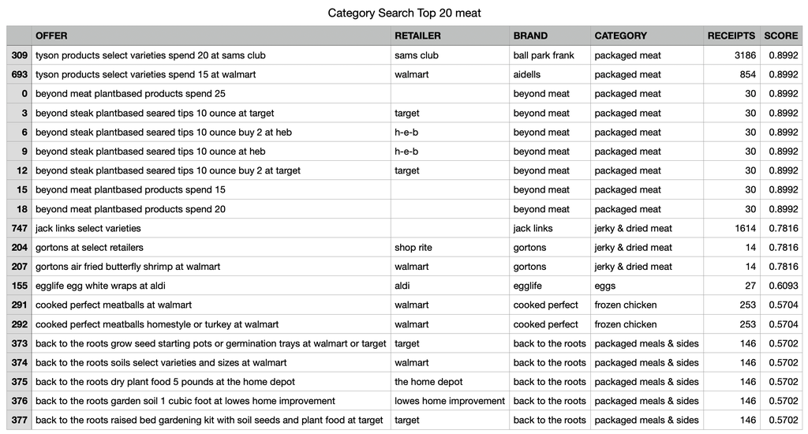

The results of top 20 offers by searching 'coffee' in category are shown below.

[figure not shown]

### Task 2. Brand Search

Similar to the category search, if the brand entered is correct or close enough to brands in the offer_retailer file, the corresponding offers will be directly outputted, just like the category search. However, this is not always the case. Note that some brands may not match with the offer_retailer table. In such cases, I will search the brand in the brand table, and use the top N (default = 3) matched categories to return all offers based on that.

```python
def brandSearch(query: str, cutoff = 0.9, N = 10):
    """
    Searching the brand in the joined full table.
    query: a single string input of search in brand
    return: a dataframe with the last column is the similarity score between the query and brand in each row
    """
    query = query.lower()
    brandDict = full['BRAND'].to_list()
    brandDict_vecs = model.encode(brandDict)
    similarity = full.copy()
    q = model.encode([query])
    cos = cosine_similarity(q, brandDict_vecs).round(4)
    similarity['SCORE'] = cos.reshape(-1, 1)
    df = similarity.copy()
    df.sort_values(by=['SCORE', 'RECEIPTS'], ascending=[False, False])
    brandOut = df[df['SCORE'] >= cutoff]

    # case one: if the brand search can identify something
    if brandOut.shape[0] > 0:
        brandOut.drop_duplicates(subset=['OFFER'], inplace = True)
        # top N offers
        b = brandOut.iloc[:N][['OFFER', 'RETAILER', 'BRAND', 'CATEGORY', 'RECEIPTS', 'SCORE']]
        fname = f'Brand Search Top {N} {query}.csv'
        # print the result here, and save to a csv file
#         print(fname)
#         print(b)
        b.to_csv(fname)
    # case two: if the brand search cannot identify any matching
    else:
        print('No good matching found in the offer table. Searching the brand_category list instead. ')
        brandOut = brandToCatSearch(query)
        if brandOut.shape[0] == 0:
            print('No matching found, please double check your input')
            return
        return brandOut
```

```python
def brandToCatSearch(query, N = 30, k = 3):
    """
    Searching the brand in the brand_category table instead.
    query: a string input of search in brand
    return: a dataframe with the last column is the similarity score between the query and brand in each row
    """

    brandDict = brand['BRAND'].to_list()
    brandDict_vecs = model.encode(brandDict)
    similarity = brand.copy()
    q = model.encode([query])
    cos = cosine_similarity(q, brandDict_vecs).round(4)
    similarity[query] = cos.reshape(-1, 1)
    df = similarity.copy()
    sortdf = df.sort_values(by=[query, 'RECEIPTS'], ascending=[False, False])

    match = sortdf.iloc[:k]
    # this match returns the top k matched category, by searching in the brand-category table
    print(f'Top {k} matched category')
    print(match)

    queryLst, scores = match['CATEGORY'].to_list(), match[query].to_list()

    catDict = full['CATEGORY'].to_list()
    catDict_vecs = model.encode(catDict)
    similarity = full.copy()
    query = model.encode(queryLst)
    cos = cosine_similarity(query, catDict_vecs).round(4)
    for i, q in enumerate(queryLst):
        similarity[q] = cos[i].reshape(-1, 1)
    df = similarity.copy()

    df[queryLst] = df[queryLst]*scores
    df[queryLst].round(4)
    df['SCORE'] = df[queryLst].max(axis=1)
    df.drop(columns=queryLst, inplace = True)
    df.drop_duplicates(subset=['OFFER'], inplace = True)

    sortdf = df.sort_values(by=['SCORE', 'RECEIPTS'], ascending=[False, False])

    out = sortdf.iloc[:N]
    fname = f'Brand Search through Category - Top {N}_{q} Match.csv'
    out.to_csv(fname)
    print()
    print(fname)
    print(out)
    return out
```

**Example 1:** The searching input is in the offer_retailer table. The search results are shown below:

```python
brandQuery = 'cvs'
res = brandSearch(brandQuery)
```

[figure not shown]

**Example 2:** The search input is in the offer_retailer table. Note that KFC is in the offer_retailer table, but not in the brand_category table. The search results are shown below:

```python
brandQuery = 'kfc'
res = brandSearch(brandQuery)
```

[figure not shown]

**Example 3:** The search input is not in the offer_retailer table. In this case, the algorithm will:

Find the top k (default 3) matched categories by searching in the brand_category table. Then, search these categories in the full table and return the top N (default 30) scored offers. If the scores are the same, the offers are ranked by receipts. The score is calculated by the similarity between the brand and category (step 1) multiplied by the score in category (step 2).

```python
brandQuery = 'Kroger'
res = brandSearch(brandQuery)
```

```
No good matching found in the offer table. Searching the brand_category list instead.
Top 3 matched category
      BRAND            CATEGORY  RECEIPTS  kroger
6    kroger              bakery    251276     1.0
430  kroger  household supplies      5255     1.0
473  kroger               water      4823     1.0

Brand Search through Category - Top 30_water Match.csv
                             OFFER         RETAILER  \
264  artesano buns buy 2 at wal...          walmart
605  glad trash bags 4 or 8 gallon
657  glad forceflex max strengt...
501            ballpark buns buy 2
473  core hydration select vari...          walmart
684  core hydration select vari...          walmart
```

[output cut: 88 more lines]

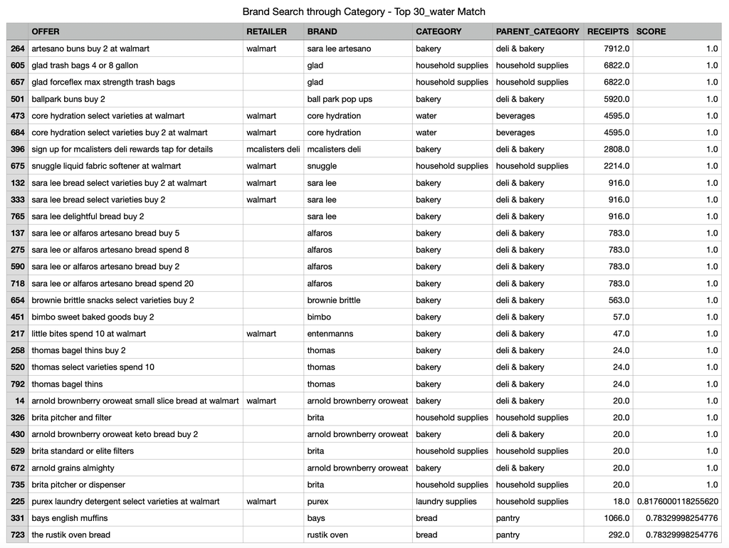

### Task 3. Retailer Search

Retailer search is more challenging than the other two, as the **offer_retailer** table is the only table that contains retailer information. Therefore, I only search in the full table and return related retailers without linking them to categories (like brand search).

```python
def retailerSearch(query: str, N = 10):
    """
    query: a single string inputs of search in retailer.
    N: top N offers selected by the matching. default 10.
    return: a csv files stores the top N selected retailer matching.
    """
    retDict = full['RETAILER'].to_list()
    retDict_vecs = model.encode(retDict)
    similarity = full.copy()
    q = model.encode([query])
    cos = cosine_similarity(q, retDict_vecs).round(4)
    similarity['SCORE'] = cos.reshape(-1, 1)
    df = similarity.copy()

    # Display the result, top N matched offer
    df.drop_duplicates(subset=['OFFER'], inplace = True)
    a = df.sort_values(by=['SCORE', 'RECEIPTS'], ascending=[False, False])
    # top N offers
    a = a.iloc[:N][['OFFER', 'RETAILER', 'BRAND', 'CATEGORY', 'RECEIPTS', 'SCORE']]
    fname = f'Retailer Search Top {N} {query}.csv'
    a.to_csv(fname)
```

```python
queries = 'CVS'
res = retailerSearch(queries)
```

The results are shown below:

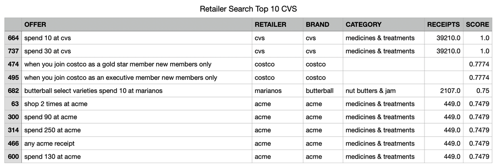

## 7. Summary

In summary, I have presented a command-line tool that enables users to intelligently search for offers via text input from users. The tool is built on natural language processing (NLP) models for performing similarity search on a dataset of product categories.

Some potential optimizations that could further improve the searching include:

- **Making the tool dynamic and real-time**: The current tool depends on the static, offline data provided. I plan to make the tool more scalable so that it can be used to process large datasets.
- **Training a sentence transformer model**: Sentence transformer models are a type of NLP model that have been shown to be effective for similarity search. By training a sentence transformer model on a dataset of product categories, I can create a model that can effectively measure the similarity between two product categories.
- **Investigating the use of other NLP models**: There are a variety of other NLP models that could be used for similarity search. I plan to investigate the use of these models to see if they can improve the performance of our tool.
- **Developing a user interface**: The current tool is a command-line tool. I plan to develop a user interface for the tool so that it can be used by a wider range of users.

## 8. References:

Sentence-Transformer library: https://www.sbert.net/docs/usage/semantic_textual_similarity.html  
bert-base-nli-mean-tokens model: https://huggingface.co/sentence-transformers/bert-base-nli-mean-tokens  
all-MiniLM-L6-v2 model https://huggingface.co/sentence-transformers/all-MiniLM-L6-v2  
cosine similarity: https://scikit-learn.org/stable/modules/generated/sklearn.metrics.pairwise.cosine_similarity.html#sklearn.metrics.pairwise.cosine_similarity